# Weight Lifting Style Classification

Derek Slone-Zhen

20/12/2014

# Project Brief

This projects uses sensor data collected from wearable-devices to evaluate *how well* participants perform a particular exercise. It analyses data collected by Velloso, Bulling, Gellersen, Ugulino, & Fuks, that classifies the performance of the exercise as “A”, “B”, “C”, “D” or “E”.

“Participants were asked to perform one set of 10 repetitions of the Unilateral Dumbbell Biceps Curl in five different fashions: exactly according to the specification (Class A), throwing the elbows to the front (Class B), lifting the dumbbell only halfway (Class C), lowering the dumbbell only halfway (Class D) and throwing the hips to the front (Class E). Class A corresponds to the specified execution of the exercise, while the other 4 classes correspond to common mistakes.” [Velloso, E.; Bulling, A.; Gellersen, H.; Ugulino, W.; Fuks, H. Qualitative Activity Recognition of Weight Lifting Exercises. Proceedings of 4th International Conference in Cooperation with SIGCHI (Augmented Human ’13) . Stuttgart, Germany: ACM SIGCHI, 2013. http://groupware.les.inf.puc-rio.br/har#weight_lifting_exercises, http://groupware.les.inf.puc-rio.br/public/papers/2013.Velloso.QAR-WLE.pdf]

The remit is to develop a classification model based on training data and then use this to predict the classification of 20 test samples.

# Summary of Outcome

I developed a 10-fold cross validated random forest using the [caret](http://topepo.github.io/caret/index.html) package in R. The expected out-of-bag error rate was 0.43%, and it correctly predicted all 20 of the test samples.

# Procedure

## Data Aquisition and Cleaning

The training and test data was downloaded from https://d396qusza40orc.cloudfront.net/predmachlearn/pml-training.csv and https://d396qusza40orc.cloudfront.net/predmachlearn/pml-testing.csv respectively.

The test and training data are read in and the first 7 “book-keeping” columns dropped. Many of the columns in the `test` data-set have only NA values, therefore we isolate these and drop them from the `test` set, together with the final column `problem_id`, which is just a sequence number. For the training set, we isolate the response variable `classe` into a `y` variable, and then restrict the training dataset to be just those columns that we have kept in the test set, since only these columns will be usable when predicting for our test set.

Having followed this procedure, this manages to remove many problematic columns in the training set with sparse columns, NAs, and “`#DIV/0!`”s that we would otherwise have to manage through imputation or default variables. By focusing on the variables that are present in the test set, these questions become irrelevant, since these columns would be unusable in our predictions anyway.

```r
train <- read.csv("pml-training.csv"); train <- train[,-(1:7)]
test <- read.csv("pml-testing.csv"); test <- test[,-(1:7)]
badCols <- which(sapply(test,function(col) all(is.na(col))))
test <- test[,-badCols]; test <- test[,-which(colnames(test)=='problem_id')]
y <- train[,'classe'];
train <- train[, colnames(test)]
```

```r
colnames(test) # so we can see what we kept
```

```
##  [1] "roll_belt"            "pitch_belt"           "yaw_belt"
##  [4] "total_accel_belt"     "gyros_belt_x"         "gyros_belt_y"
##  [7] "gyros_belt_z"         "accel_belt_x"         "accel_belt_y"
## [10] "accel_belt_z"         "magnet_belt_x"        "magnet_belt_y"
## [13] "magnet_belt_z"        "roll_arm"             "pitch_arm"
## [16] "yaw_arm"              "total_accel_arm"      "gyros_arm_x"
## [19] "gyros_arm_y"          "gyros_arm_z"          "accel_arm_x"
## [22] "accel_arm_y"          "accel_arm_z"          "magnet_arm_x"
## [25] "magnet_arm_y"         "magnet_arm_z"         "roll_dumbbell"
## [28] "pitch_dumbbell"       "yaw_dumbbell"         "total_accel_dumbbell"
## [31] "gyros_dumbbell_x"     "gyros_dumbbell_y"     "gyros_dumbbell_z"
## [34] "accel_dumbbell_x"     "accel_dumbbell_y"     "accel_dumbbell_z"
## [37] "magnet_dumbbell_x"    "magnet_dumbbell_y"    "magnet_dumbbell_z"
## [40] "roll_forearm"         "pitch_forearm"        "yaw_forearm"
## [43] "total_accel_forearm"  "gyros_forearm_x"      "gyros_forearm_y"
## [46] "gyros_forearm_z"      "accel_forearm_x"      "accel_forearm_y"
## [49] "accel_forearm_z"      "magnet_forearm_x"     "magnet_forearm_y"
## [52] "magnet_forearm_z"
```

## Initial Data Analysis

The data was checked for “odd” variables and obvious classification candidates using featurePlot with box-plots, but none were found. (And the output is therefore suppressed for brevity.)

```r
featurePlot(x=train, y=y, plot='box',
            scales = list(y = list(relation="free"), x = list(rot = 90)),
            layout = c(4,1 ), auto.key = list(columns = 2))
summary(train)
```

## Method Selection

Given that many of the variables are vectorised into `x`, `y` and `z` components, it seems inappropriate to use any linear method since we would almost certainly have to create additional factors such as absolute size of the vector (or, at least, investigate the need for such). Of the non-linear methods, I was most familiar with neural networks and random forests. I opted for random forests as this is what the original researched had used (with good success). I also followed their strategy of using 10-fold cross validation, and added in 4-repeats for good measure.

Of particular importance is that, when using an n-fold cross-validation mechanism, the out-of-bag error is created, accumulated and aggregated across all of the runs of the training, allowing the training process to internally calculate out-of-bag error without the need to separate out an explicit cross-validation set from the training set. (Grader: so, please don’t dock me the mark for not explicitly partitioning the data into train and cross-validation, as this *is* happening internally during the training!)

```r
set.seed(73549)
seeds <- vector(mode = "list", length = 41)
for(i in 1:40) seeds[[i]]<- sample.int(1000, 3)
seeds[[41]]<-sample.int(1000, 1)#for the last model
str(seeds)
fitControl <- trainControl(## 10-fold CV
                           method = "repeatedcv",
                           number = 10,
                           ## repeated ten times
                           repeats = 4,
                           seeds=seeds)

m <- train(x = train, y = y, model='rf', trControl = fitControl)
```

## Evaluation

### Out-Of-Bag Error Rate (OOB)

The final random forest shows an estimated out-of-bag (OOB) error rate of 0.43%.

```r
m$finalModel
```

```
##
## Call:
##  randomForest(x = x, y = y, mtry = param$mtry, model = "rf")
##                Type of random forest: classification
##                      Number of trees: 500
## No. of variables tried at each split: 2
##
##         OOB estimate of  error rate: 0.43%
## Confusion matrix:
##      A    B    C    D    E  class.error
## A 5578    1    0    0    1 0.0003584229
## B   10 3781    6    0    0 0.0042138530
## C    0   18 3403    1    0 0.0055523086
## D    0    0   38 3175    3 0.0127487562
## E    0    0    0    6 3601 0.0016634322
```

That is, on unseen data, the model is expecting to make an error only 1 in 200 times.

Looking at the confusion matrix produced by having the model predict on the original training data shows a perfect confusion matrix.

```r
confusionMatrix(y, predict(m))$table
```

```
##           Reference
## Prediction    A    B    C    D    E
##          A 5580    0    0    0    0
##          B    0 3797    0    0    0
##          C    0    0 3422    0    0
##          D    0    0    0 3216    0
##          E    0    0    0    0 3607
```

The internally constructed OOB rate includes insights from how the individual trees performed during cross validation. Looking at the predicted OOB error rate at a cumulative tree level shows us that the OOB rapidly decreases.

```r
head(m$finalModel$err.rate,n=30)
```

```
##              OOB           A          B          C          D           E
##  [1,] 0.11311339 0.076139670 0.14478353 0.14516129 0.12816042 0.091962906
##  [2,] 0.11554837 0.073853484 0.15053286 0.14889529 0.13955929 0.090400746
##  [3,] 0.11234501 0.074374255 0.13802917 0.14804793 0.12772194 0.096774194
##  [4,] 0.10769044 0.069163652 0.14097331 0.13849358 0.11897702 0.093153390
##  [5,] 0.10286878 0.067118104 0.13173302 0.14206941 0.11118785 0.083205404
##  [6,] 0.09120096 0.059228124 0.11580727 0.12655860 0.09707447 0.076080521
##  [7,] 0.08144964 0.049552906 0.10973937 0.10607903 0.08875931 0.071180556
##  [8,] 0.07209655 0.043510189 0.09789644 0.09129003 0.08314679 0.061114269
##  [9,] 0.06400829 0.040597124 0.08624833 0.08167508 0.07283091 0.052156752
## [10,] 0.05544972 0.033000907 0.07520595 0.07048068 0.06886792 0.043088976
## [11,] 0.04906183 0.027572536 0.06675497 0.06317955 0.06426332 0.036779047
## [12,] 0.04362725 0.024824609 0.05866808 0.05689150 0.06093750 0.028896916
## [13,] 0.03885627 0.020100503 0.05593668 0.05389572 0.05084217 0.024979184
## [14,] 0.03581633 0.018827327 0.05034265 0.04564073 0.05269722 0.022475028
```

[output cut: 16 more lines]

### Number of trees

Plotting of the OOB error rate by tree in the forest (see below) shows that allowing `caret` to default to 500 trees was well into diminishing returns, even 80 trees would have been more than sufficient.

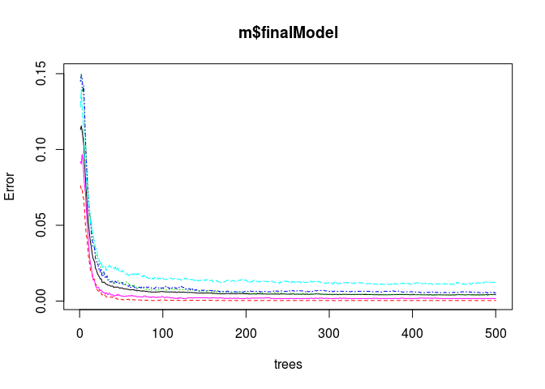

```r
plot(m$finalModel)
```

### mtry : Number of variables randomly sampled as candidates at each split

Also, very much to my surprise, the optimal `mtry` selected by `caret` was just two. This may be as a result of heavy pruning of the poorly performing trees, and the fact there was plenty of scope (10-folds × 4 repeats) within which such “natural selection” could occur.

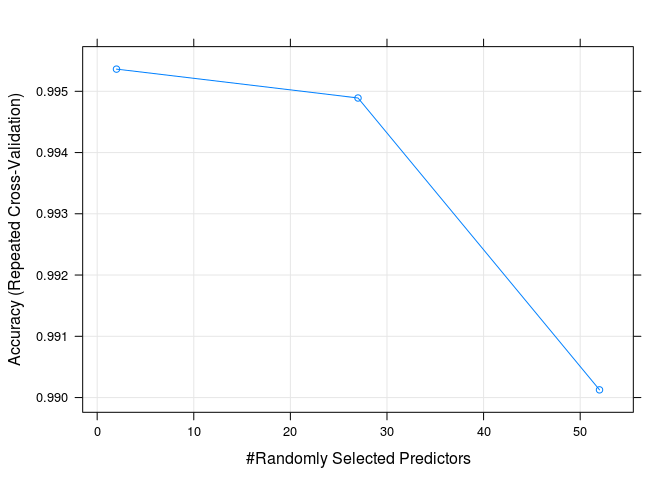

```r
plot(m)
```